# Anàlisi de dades òmiques (M0-157). PAC1.

Marc Anton

2025-04-01

# 1. Introducció

Aquest arxiu conté les sol·lucions analítiques als problemes plantejats en la PAC1 *Anàlisi de dades òmiques (M0-157)*. El projecte total del treball es pot consultar al: meu repositori github, cliqueu **[aquí](https://github.com/MarcAnton1968/Anton_Recasens_Marc_PAC1/tree/master)**

# 2. Carrega de dades

Abans que res, carreguem les dades al nostre entorn de treball. Treballarem amb un dels exemples de mostra, veure **aquí**. Aquest exemple porta dos arxius, DataInfo_S013 i DataValues_S013. Carreguem els dos fitxers:

```r
DataInfo_S013 <- read.csv("DataInfo_S013.csv", sep = ",")
DataValues_S013 <- read.csv("DataValues_S013.csv", sep = ",")
```

Com és habitual amb dades òmiques, tenim moltes varibales i un nombre reduït de casos d’estudi. Tot i així, abans que res mirem l’estructura dels dos.

# 3. Eploració previa de les dades descarregades

```r
dim(DataInfo_S013)
```

```
## [1] 695   4
```

```r
dim(DataValues_S013)
```

```
## [1]  39 696
```

Aqui ja veiem que en l’arxiu Info hi ha 695 files que han de correspondre a les variables que hi ha a Values. En aquest darrer tenim 696 columnes i 39 files. Les files corresponen a cada cas d’estudi més les 695 columnes són les variables que es tenen de cada un d’ells.

Per veure què són les variables, mirem les 20 primeres files d’Info i podem fer-nos una idea.

```r
head(DataInfo_S013,20)
```

```
##                    X           VarName    varTpe Description
## 1           SUBJECTS          SUBJECTS   integer    dataDesc
## 2            SURGERY           SURGERY character    dataDesc
## 3                AGE               AGE   integer    dataDesc
## 4             GENDER            GENDER character    dataDesc
## 5              Group             Group   integer    dataDesc
## 6           MEDDM_T0          MEDDM_T0   integer    dataDesc
## 7          MEDCOL_T0         MEDCOL_T0   integer    dataDesc
## 8          MEDINF_T0         MEDINF_T0   integer    dataDesc
## 9          MEDHTA_T0         MEDHTA_T0   integer    dataDesc
## 10            GLU_T0            GLU_T0   integer    dataDesc
## 11            INS_T0            INS_T0   numeric    dataDesc
## 12           HOMA_T0           HOMA_T0   numeric    dataDesc
## 13          HBA1C_T0          HBA1C_T0   numeric    dataDesc
## 14 HBA1C.mmol.mol_T0 HBA1C.mmol.mol_T0   numeric    dataDesc
## 15           PESO_T0           PESO_T0   integer    dataDesc
## 16            bmi_T0            bmi_T0   numeric    dataDesc
## 17             CC_T0             CC_T0   numeric    dataDesc
## 18           CINT_T0           CINT_T0   integer    dataDesc
## 19            CAD_T0            CAD_T0   integer    dataDesc
## 20            TAD_T0            TAD_T0   integer    dataDesc
```

Aqui ja veiem que hi ha 9 primers camps que semblen ser els que tenen la informació sobre el pacient de cada mostra. Mirem que contenen aquests camps a values:

```r
# En mirem 10 en realitat, per comprovar que la primera columna és un index
head(DataValues_S013[,1:10])
```

```
##   X.1 SUBJECTS SURGERY AGE GENDER Group MEDDM_T0 MEDCOL_T0 MEDINF_T0 MEDHTA_T0
## 1   1        1 by pass  27      F     1        0         0         0         1
## 2   2        2 by pass  19      F     2        0         0         0         0
## 3   3        3 by pass  42      F     1        0         0         0         0
## 4   4        4 by pass  37      F     2        0         0         0         0
## 5   5        5 tubular  42      F     1        0         0         0         0
## 6   6        6 by pass  24      F     2        0         0         0         0
```

Com suposavem, aquestes columnes corresponen a: 1. Un codi de pacient (que està repetit a les dues primeres columnes, d’aquí que hi hagi una fila més a Info que columnes a Values) 2. La cirugia a la que va ser sotmés el pacient 3. L’edat i el gènere 4. Un grup de tractament 5. 4 tractaments que venen amb 0 i 1

Per veure que la resta són variables metabòliques, mirem 10 columnes més

```r
head(DataValues_S013[,11:20],10)
```

```
##    GLU_T0 INS_T0 HOMA_T0 HBA1C_T0 HBA1C.mmol.mol_T0 PESO_T0 bmi_T0 CC_T0
## 1      85  11.40    2.40       NA                NA     151   62.9   0.7
## 2      78  12.10    2.32       NA                NA     139   47.0    NA
## 3      75   8.41    1.56      5.4             35.51      84   29.8   0.7
## 4      71  12.80    2.25      5.1             32.23     136   53.1   1.0
## 5      82   6.01    1.22      5.6             37.69     121   46.6   0.9
## 6      71   9.88    1.73      5.1             32.23     148   48.8   0.7
## 7      80   9.20    1.82      5.6             37.69     109   43.7   0.9
## 8      90   3.40    0.76      5.5             36.60     109   41.8   0.9
## 9      92   5.43    1.23      5.7             38.78     114   44.0   0.9
## 10     84   6.98    1.45      5.5             36.60     120   40.6    NA
##    CINT_T0 CAD_T0
## 1      116    167
## 2       NA     NA
## 3       90    126
## 4      157    162
## 5      123    132
## 6      110    148
## 7      122    141
## 8      124    136
## 9      136    148
## 10      NA     NA
```

Obviament ja ho veiem i també podem veure que hi ha més d’un valor que no es té per a alguna de les variables (NA). Anem a veure si n’hi ha molts

```r
sum(is.na(DataValues_S013))/(dim(DataValues_S013)[1]*dim(DataValues_S013)[2])
```

```
## [1] 0.1248895
```

Això apunta a que tenim un 12,5% de valors desconeguts. Aquest és un aspecte que caldrà tenir en compte en els anàlisi posteriors

# 4. Generació de l’obsject SummarizedExperiment

Ara que ja sabem que tenim a les dades, podem procedir a carregar-les en un objecte *SummarizedExperiment*. Per a fer-ho, convertirem però les dades a un data frame i li traurem la primera columna que ja hem vist que és redundant amb la segona. Aleshores ja ho podem carregar. En concret, carregarem:

```r
# Primer carreguem la llibreria per poder tractar el SummarizedExperiment
library(SummarizedExperiment)
# Després generem les dades de pacients i de metabolits i la llista de rownames que volem tal i com hem indicat al text
pacients <- DataValues_S013[,2:10]
metabolits <- DataValues_S013[,11:696]
colNames <- DataInfo_S013[10:695,]
# Ara ja podem carregar el SummarizedExperiment
seMA <- SummarizedExperiment(assays = list(counts = as.matrix(metabolits)),
                             colData = colNames,
                             rowData = pacients)
seMA
```

```
## class: SummarizedExperiment
## dim: 39 686
## metadata(0):
## assays(1): counts
## rownames: NULL
## rowData names(9): SUBJECTS SURGERY ... MEDINF_T0 MEDHTA_T0
## colnames(686): GLU_T0 INS_T0 ... SM.C24.0_T5 SM.C24.1_T5
## colData names(4): X VarName varTpe Description
```

Sembla que l’objecte s’ha generat correctament

Mirem un parell de funcions que es poden fer.

```r
# Comprovem com es diuen les columnes que tenim en cada una de les classes de dins de l'objecte
dimnames(seMA)
```

```
## [[1]]
## NULL
##
## [[2]]
##   [1] "GLU_T0"            "INS_T0"            "HOMA_T0"
##   [4] "HBA1C_T0"          "HBA1C.mmol.mol_T0" "PESO_T0"
##   [7] "bmi_T0"            "CC_T0"             "CINT_T0"
##  [10] "CAD_T0"            "TAD_T0"            "TAS_T0"
##  [13] "TG_T0"             "COL_T0"            "LDL_T0"
##  [16] "HDL_T0"            "VLDL_T0"           "PCR_T0"
##  [19] "LEP_T0"            "ADIPO_T0"          "GOT_T0"
##  [22] "GPT_T0"            "GGT_T0"            "URICO_T0"
##  [25] "CREAT_T0"          "UREA_T0"           "HIERRO_T0"
##  [28] "TRANSF_T0"         "FERR_T0"           "Ile_T0"
##  [31] "Leu_T0"            "Val_T0"            "Ala_T0"
```

[output cut: 218 more lines]

```r
# I ara mirem les 10 primeres columnes i les 5 primeres files d'assays
assay(seMA)[1:5, 1:10]
```

```
##      GLU_T0 INS_T0 HOMA_T0 HBA1C_T0 HBA1C.mmol.mol_T0 PESO_T0 bmi_T0 CC_T0
## [1,]     85  11.40    2.40       NA                NA     151   62.9   0.7
## [2,]     78  12.10    2.32       NA                NA     139   47.0    NA
## [3,]     75   8.41    1.56      5.4             35.51      84   29.8   0.7
## [4,]     71  12.80    2.25      5.1             32.23     136   53.1   1.0
## [5,]     82   6.01    1.22      5.6             37.69     121   46.6   0.9
##      CINT_T0 CAD_T0
## [1,]     116    167
## [2,]      NA     NA
## [3,]      90    126
## [4,]     157    162
## [5,]     123    132
```

```r
# I també mirem com ha quedat colData
colData(seMA)
```

```
## DataFrame with 686 rows and 4 columns
##                                   X           VarName      varTpe Description
##                         <character>       <character> <character> <character>
## GLU_T0                       GLU_T0            GLU_T0     integer    dataDesc
## INS_T0                       INS_T0            INS_T0     numeric    dataDesc
## HOMA_T0                     HOMA_T0           HOMA_T0     numeric    dataDesc
## HBA1C_T0                   HBA1C_T0          HBA1C_T0     numeric    dataDesc
## HBA1C.mmol.mol_T0 HBA1C.mmol.mol_T0 HBA1C.mmol.mol_T0     numeric    dataDesc
## ...                             ...               ...         ...         ...
## SM.C18.0_T5             SM.C18.0_T5       SM.C18.0_T5     numeric    dataDesc
## SM.C18.1_T5             SM.C18.1_T5       SM.C18.1_T5     numeric    dataDesc
## SM.C20.2_T5             SM.C20.2_T5       SM.C20.2_T5     numeric    dataDesc
## SM.C24.0_T5             SM.C24.0_T5       SM.C24.0_T5     numeric    dataDesc
## SM.C24.1_T5             SM.C24.1_T5       SM.C24.1_T5     numeric    dataDesc
```

```r
# I les dades bàsiques dels pacients
rowData(seMA)
```

```
## DataFrame with 39 rows and 9 columns
##      SUBJECTS     SURGERY       AGE      GENDER     Group  MEDDM_T0 MEDCOL_T0
##     <integer> <character> <integer> <character> <integer> <integer> <integer>
## 1           1     by pass        27           F         1         0         0
## 2           2     by pass        19           F         2         0         0
## 3           3     by pass        42           F         1         0         0
## 4           4     by pass        37           F         2         0         0
## 5           5     tubular        42           F         1         0         0
## ...       ...         ...       ...         ...       ...       ...       ...
## 35         35     tubular        39           M         2         0         0
## 36         36     tubular        35           M         1         0         0
## 37         37     by pass        46           M         2         0         0
## 38         38     tubular        41           M         1         0         0
## 39         39     by pass        26           M         1         0         0
##     MEDINF_T0 MEDHTA_T0
##     <integer> <integer>
## 1           0         1
## 2           0         0
## 3           0         0
## 4           0         0
## 5           0         0
## ...       ...       ...
## 35          0         1
## 36          0         0
## 37          1         0
## 38          0         0
## 39          0         0
```

# 5. Anàlisi exploratoria inicial de les dades

## 5.1. Descripció de les dades

Fins ara hem vist que les nostres dades tenen NA, el que pot suposar un problema. Anem a veure també si la variabilitat de rangs és molt gran´i ens cal normalitzar les dades. Fem un summary a més per veure com varien els estadístics bàsics. Si ho fem amb tot l’arxiu no s’arriba a apreciar la sortida, així que en fem uns quants

```r
summary(assay(seMA)[,1:150])
```

```
##      GLU_T0          INS_T0         HOMA_T0          HBA1C_T0
##  Min.   : 71.0   Min.   : 3.40   Min.   : 0.760   Min.   :5.100
##  1st Qu.: 91.0   1st Qu.:11.85   1st Qu.: 2.435   1st Qu.:5.400
##  Median :103.0   Median :16.00   Median : 4.210   Median :5.600
##  Mean   :106.5   Mean   :17.60   Mean   : 4.890   Mean   :5.592
##  3rd Qu.:109.5   3rd Qu.:21.15   3rd Qu.: 5.720   3rd Qu.:5.800
##  Max.   :263.0   Max.   :43.00   Max.   :13.600   Max.   :6.400
##                                                   NA's   :15
##  HBA1C.mmol.mol_T0    PESO_T0          bmi_T0          CC_T0
##  Min.   :32.23     Min.   : 84.0   Min.   :29.80   Min.   :0.7000
##  1st Qu.:35.51     1st Qu.:119.5   1st Qu.:44.40   1st Qu.:0.9000
##  Median :37.69     Median :135.0   Median :48.80   Median :0.9000
##  Mean   :37.60     Mean   :140.0   Mean   :50.52   Mean   :0.9343
##  3rd Qu.:39.88     3rd Qu.:155.0   3rd Qu.:55.35   3rd Qu.:1.0000
##  Max.   :46.44     Max.   :200.0   Max.   :68.60   Max.   :1.7000
##  NA's   :15                                        NA's   :4
##     CINT_T0          CAD_T0          TAD_T0           TAS_T0
##  Min.   : 90.0   Min.   : 85.0   Min.   : 60.00   Min.   :111.0
##  1st Qu.:122.5   1st Qu.:136.0   1st Qu.: 74.50   1st Qu.:121.0
##  Median :133.0   Median :148.0   Median : 83.00   Median :128.0
##  Mean   :135.7   Mean   :147.1   Mean   : 83.58   Mean   :133.5
##  3rd Qu.:147.5   3rd Qu.:158.5   3rd Qu.: 90.00   3rd Qu.:144.0
##  Max.   :186.0   Max.   :182.0   Max.   :125.00   Max.   :180.0
##  NA's   :4       NA's   :4       NA's   :8        NA's   :8
##      TG_T0           COL_T0          LDL_T0          HDL_T0
##  Min.   : 30.0   Min.   :102.0   Min.   : 24.0   Min.   : 11.00
##  1st Qu.: 84.0   1st Qu.:180.5   1st Qu.:100.3   1st Qu.: 39.25
##  Median :118.0   Median :207.0   Median :130.0   Median : 47.00
##  Mean   :129.1   Mean   :206.6   Mean   :128.2   Mean   : 49.97
##  3rd Qu.:151.0   3rd Qu.:236.0   3rd Qu.:158.8   3rd Qu.: 59.50
##  Max.   :268.0   Max.   :295.0   Max.   :191.0   Max.   :107.00
##                                  NA's   :1       NA's   :1
##     VLDL_T0          PCR_T0          LEP_T0          ADIPO_T0
##  Min.   : 6.00   Min.   : 0.00   Min.   : 27.00   Min.   : 1.720
##  1st Qu.:16.80   1st Qu.: 3.51   1st Qu.: 49.25   1st Qu.: 4.700
##  Median :23.60   Median : 8.25   Median : 67.20   Median : 7.460
##  Mean   :25.81   Mean   :10.13   Mean   : 78.33   Mean   : 7.702
##  3rd Qu.:30.20   3rd Qu.:13.90   3rd Qu.: 98.25   3rd Qu.: 8.590
##  Max.   :53.60   Max.   :29.80   Max.   :155.00   Max.   :17.100
##                  NA's   :14      NA's   :13       NA's   :14
```

[output cut: 249 more lines]

```
##  Min.   :1.020   Min.   :1.050   Min.   :1.340   Min.   :0.2100
##  1st Qu.:1.645   1st Qu.:1.570   1st Qu.:1.700   1st Qu.:0.3600
##  Median :1.940   Median :1.790   Median :2.200   Median :0.4300
##  Mean   :2.380   Mean   :2.317   Mean   :2.309   Mean   :0.6195
##  3rd Qu.:2.610   3rd Qu.:2.385   3rd Qu.:3.035   3rd Qu.:0.5650
##  Max.   :7.970   Max.   :8.690   Max.   :3.540   Max.   :3.4000
##
##  PC.ae.C42.2_T0   PC.ae.C42.3_T0
##  Min.   :0.2900   Min.   :0.4600
##  1st Qu.:0.3800   1st Qu.:0.6050
##  Median :0.4700   Median :0.7900
##  Mean   :0.6236   Mean   :0.9569
##  3rd Qu.:0.6100   3rd Qu.:0.9450
##  Max.   :2.8200   Max.   :4.1900
##
```

Veiem que la variabilitat en els rangs és molt elevada i, per tant, caldrà normalitzar les dades. Recordem també que tenim un nombre de NAs força elevat el que implica fer alguna mena d’imputació per eliminar problemes computacionals.

Tot i això, abans de continuar, generaré el fitxer rdata amb seMA

```r
save(seMA, file = "AntonRecasensMarcSe.rdata")
```

## 5.2. Preprocessat

Amb el que hem pogut veure fins aquó de les dades que tenim és que ens calen dos procesos per poder començar els anàlisi multivariants:

1. Imputar els missing values
2. Normalitzar les dades

Això ho podem fer amb POMA

```r
# primer instal·lem el paquet i les llibreries
# BiocManager::install("POMA") # Això només el primer cop per instal·lar el paquet
library(POMA)
library(ggtext)
library(magrittr)
```

Ataquem primer la imputació.

Abans de fer-la cal dir que no podem imputar NA en columnes on no tenim cap valor. Per tant, mirem si hi ha alguna columna que no tingui cap valor i l’eliminem.

```r
# Busquem columnes amb tot NAs
eliminats = c()
for (i in 1:685)
  if (sum(is.na(assay(seMA)[,i])) == 39)
  {print((paste(i, sum(is.na(assay(seMA)[,i])))))
    eliminats = c(eliminats, i)}
```

```
## [1] "248 39"
```

Eliminem per tant, la columna 248

```r
seMAclean <- seMA[,-eliminats]
```

I fem la imputació dels NA utilitzant el knn que és possiblement el mètode més robust per fer-ho

```r
seMAimputed <- seMAclean %>%
  PomaImpute(method = "knn", zeros_as_na = FALSE, remove_na = FALSE, cutoff = 20)
```

```
## -39 features removed.
```

Després comprovem que no tenim NAs

```r
sum(is.na(assay(seMAimputed)))
```

```
## [1] 0
```

Doncs ara, ha podem normalitzar les dades. D’entre els mètodes que es poden utilitzar hem rebutjat els logaritmes perquè amb les dades que tenim ens generen NAs, ek mix_max perquè genera molta variabilitat en les dades en el nostre cas i el box_cox perquè no funciona amb la matriu que tenim.

Ens queden els dos mètodes d’escalat i el auto_scaling és el que dona el gràfic més homogeni. Així que ens quedem amb aquest

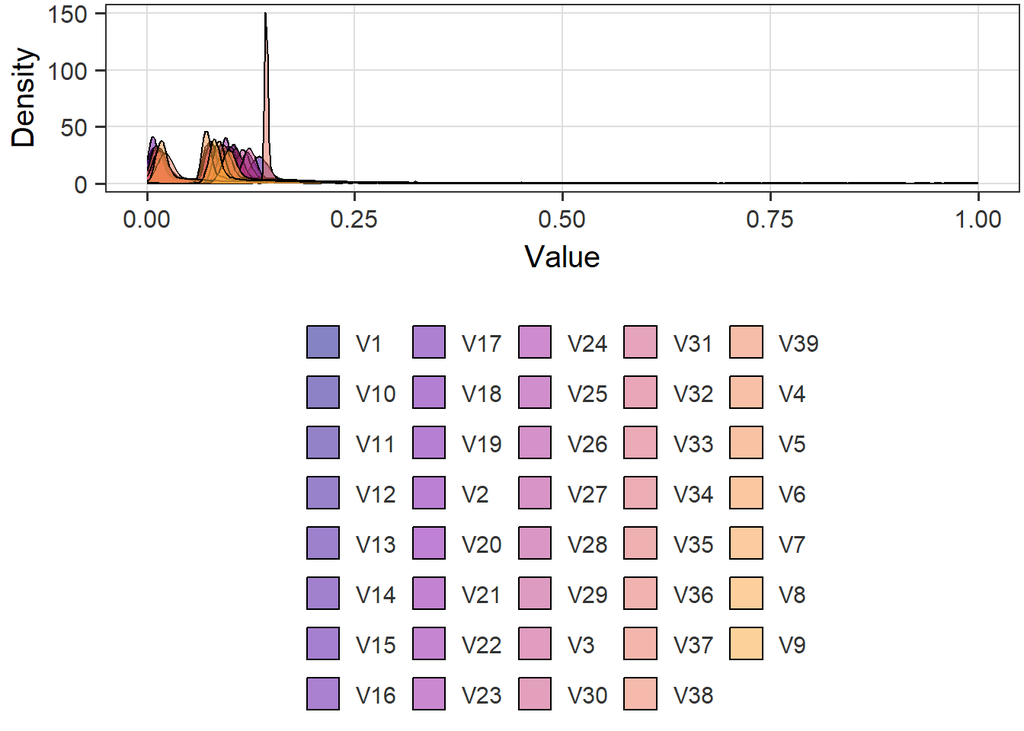

```r
# Ensenyem el resultat de min_max per veure que les funcions de densitat són molt variables
seMAnormalized <- seMAimputed %>%
  PomaNorm(method = "min_max")
PomaDensity(seMAnormalized, x = "features")
```

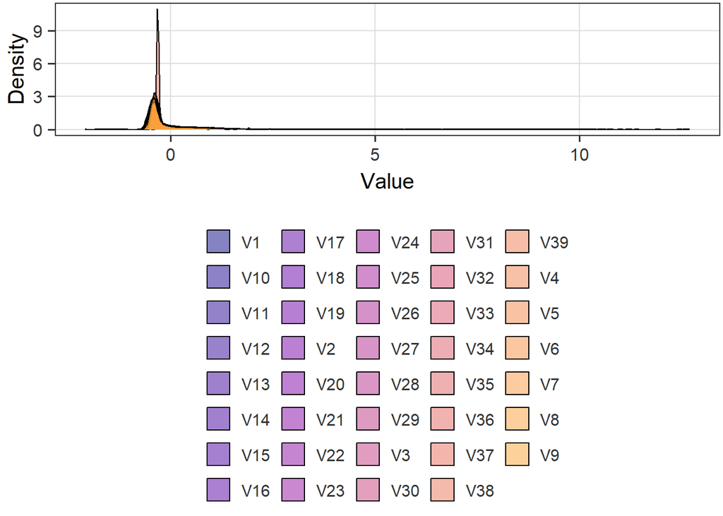

```r
# Ensenyem el resultat de min_max per veure que les funcions de densitat són molt variables
seMAnormalized <- seMAimputed %>%
  PomaNorm(method = "auto_scaling")
PomaDensity(seMAnormalized, x = "features")
```

Sembla que hi ha algun outlier, però crec que no és preocupant

## 5.4. Analisi univariant

L’anàlisi univariant no té massa sentit amb una matriu tant gran de dades, però per provar alguna cosa, podem dir que fer alguns histogrames no està de mas. Farem 9 de les variables per veure una mica com es distribueixen després del preprocessament

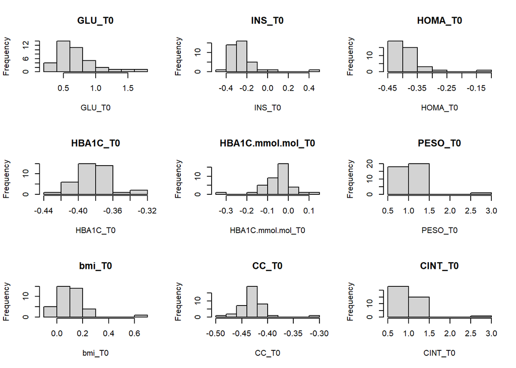

```r
opt <- par(mfrow=c(3,3))
for (i in 1:9)
  hist(assay(seMAnormalized)[,i],
       xlab = colData(seMAnormalized)[i,2],
       main = colData(seMAnormalized)[i,2])
```

```r
par(opt)
```

Podem apreciar que les distribucions no són molt homogenies, el que potser implica poques correlacions. Veurem més endavant

# 6. Reducció de les dimensions

Un pas important ara que hem vist com són les variables pot ser fer un Anàlisi de Components Principals (PCA)). Com que tenim els NAs eliminats i les dades normalitzades, podem fer-lo sense problemes addicionals. Reduim la PCA a 5 components ja que sinó en fa 39 i el resultat s’allarga molt

```r
PCAseMA <- prcomp(assay(seMAnormalized), scale. = TRUE, rank. = 5)
PCAseMA
```

```
## Standard deviations (1, .., p=39):
##  [1] 1.893256e+01 7.377935e+00 5.806778e+00 5.366514e+00 5.212884e+00
##  [6] 4.421286e+00 4.032098e+00 3.610802e+00 3.464758e+00 2.993985e+00
## [11] 2.905096e+00 2.840228e+00 2.671005e+00 2.633563e+00 2.591891e+00
## [16] 2.550440e+00 2.438817e+00 2.282599e+00 2.222872e+00 2.118927e+00
## [21] 2.067725e+00 2.042961e+00 1.985076e+00 1.889037e+00 1.853185e+00
## [26] 1.802430e+00 1.759200e+00 1.735222e+00 1.711374e+00 1.624513e+00
## [31] 1.531975e+00 1.494274e+00 1.382320e+00 1.374211e+00 1.328333e+00
## [36] 1.224837e+00 1.109147e+00 1.021286e+00 1.161219e-14
##
## Rotation (n x k) = (685 x 5):
##                             PC1           PC2           PC3           PC4
## GLU_T0            -1.199624e-02  4.941264e-02 -2.319322e-02 -1.078391e-02
## INS_T0            -3.040036e-02  5.672071e-02 -2.721737e-02  2.233584e-02
## HOMA_T0           -4.080096e-02  3.104342e-02 -2.125132e-02  7.222602e-03
## HBA1C_T0          -4.651415e-02 -1.834343e-02  2.008314e-02 -5.565033e-04
## HBA1C.mmol.mol_T0  3.552732e-02 -9.188496e-03  2.104319e-02  4.572940e-04
## PESO_T0           -2.326499e-02  8.125680e-02 -3.630520e-02 -3.611425e-03
## bmi_T0            -2.471270e-02  8.087699e-02 -3.633006e-02  1.303281e-02
## CC_T0             -5.244727e-02 -1.569056e-03  6.832376e-03  6.712868e-03
## CINT_T0           -2.108588e-02  1.005267e-01 -1.260106e-02  2.898376e-02
## CAD_T0            -1.094508e-02  1.031612e-01 -1.546234e-02 -6.292826e-03
## TAD_T0             3.368663e-02 -5.542617e-03  1.880689e-02 -1.076498e-02
## TAS_T0             4.155077e-02 -5.256121e-04  3.309474e-03 -4.469568e-03
## TG_T0              4.626877e-03  2.775474e-02 -5.204236e-02  5.830628e-02
## COL_T0            -3.209452e-03  4.890035e-02 -1.392578e-02  2.888548e-02
## LDL_T0            -9.495424e-03  6.748697e-02 -1.252003e-02  2.204182e-02
## HDL_T0             6.530946e-04 -3.647308e-02  2.226752e-02 -1.236797e-02
## VLDL_T0           -4.486175e-03  2.630072e-02 -5.128724e-02  5.894473e-02
## PCR_T0            -1.594345e-02 -2.534249e-02  2.709684e-02 -1.312719e-02
## LEP_T0            -2.977204e-02  5.974349e-02 -1.459339e-02  5.927173e-03
## ADIPO_T0          -2.157399e-02  5.445112e-03 -1.229830e-02 -2.448064e-02
## GOT_T0            -1.097243e-02  3.930316e-03  3.068829e-02  3.609539e-03
## GPT_T0            -1.042910e-02  6.848081e-03 -1.324231e-02 -8.294370e-03
## GGT_T0            -2.106519e-02  5.718606e-02 -4.429951e-02  4.709703e-02
## URICO_T0          -4.690040e-02  3.257911e-02 -1.050633e-02  2.145387e-02
## CREAT_T0          -5.238177e-02 -4.462782e-03  7.125217e-03  3.583363e-04
## UREA_T0           -1.102555e-02  4.186594e-02 -8.738753e-03  3.110859e-02
## HIERRO_T0         -3.876584e-03  4.665753e-02 -5.411954e-03  2.833490e-02
## TRANSF_T0          3.990148e-02 -6.735974e-03  1.411681e-02  2.756888e-02
```

[output cut: 1328 more lines]

```
## PC.ae.C44.4_T5     5.611252e-03
## PC.ae.C44.5_T5     2.671604e-03
## PC.ae.C44.6_T5     6.367906e-03
## SM..OH..C14.1_T5   5.134371e-03
## SM..OH..C16.1_T5   1.238687e-03
## SM..OH..C22.1_T5  -2.926439e-02
## SM..OH..C22.2_T5  -3.646292e-03
## SM..OH..C24.1_T5  -1.647480e-03
## SM.C16.0_T5        9.260947e-03
## SM.C16.1_T5        2.088881e-02
## SM.C18.0_T5        2.338297e-03
## SM.C18.1_T5        1.268094e-02
## SM.C20.2_T5        2.555965e-04
## SM.C24.0_T5       -2.272492e-02
## SM.C24.1_T5        3.476208e-03
```

```r
summary(PCAseMA)
```

```
## Importance of first k=5 (out of 39) components:
##                            PC1     PC2     PC3     PC4     PC5
## Standard deviation     18.9326 7.37793 5.80678 5.36651 5.21288
## Proportion of Variance  0.5233 0.07947 0.04922 0.04204 0.03967
## Cumulative Proportion   0.5233 0.60274 0.65196 0.69401 0.73368
```

L’anàlisi no és molt concloent. Per obtenir un 70% de la variancia ens calen 5 components, el que és molt. Entenc que hi ha massa variables en joc i segurament caldria reduir abans d’alguna altra manera. Segurament hi ha explicacions biològiques que estaria bé aplicar, però a mi se m’escapen ja que no comprenc totes les variable i per tant, acoto aquí.

Tot i això, per veure com evoluciona l’explicació de la variança faig un gràfic de barres amb una nova PCA que porta tots els components

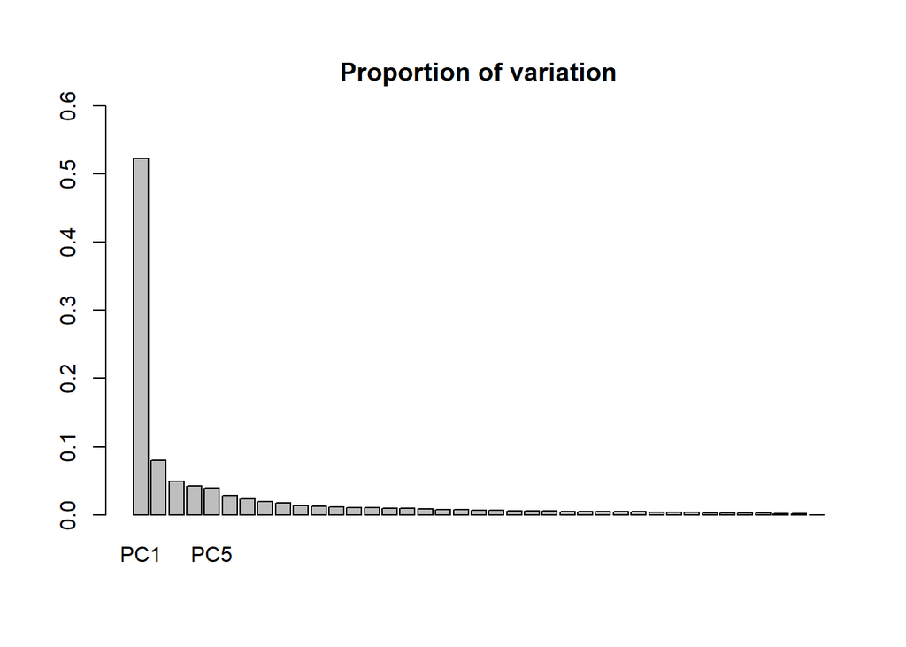

```r
barplot(summary(PCAseMA)$importance[2,],ylim=c(0,0.6))
title(main="Proportion of variation",line=1)
```

S’parecia força clar com la primera aporta força i les següents van afegint poc. Tot i això, podriem dir que fins a la cinquena sembla interessant agafarles.

Grafiquem ara les primeres components i ho fem en relació al tipus de cirugia que és el que cerca l’article original. De moment, dues

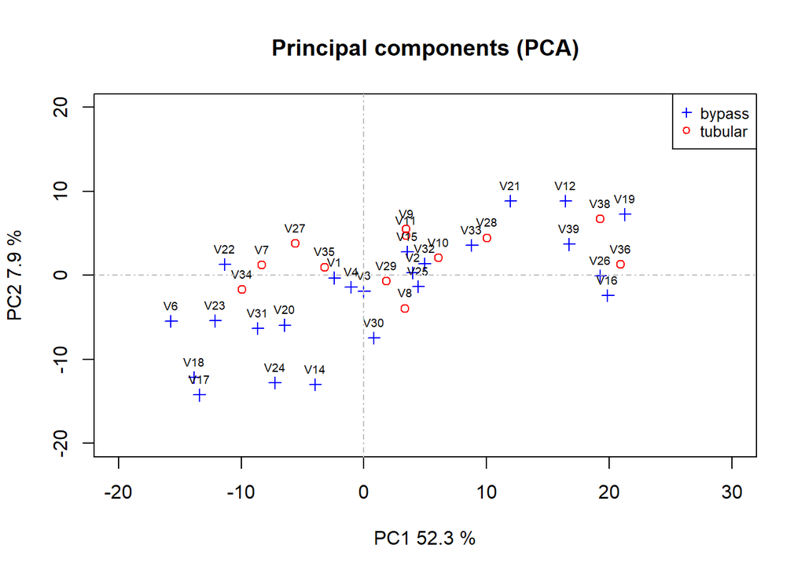

```r
# carreguem les dades pel gràfic
cirugia <- as.factor(rowData(seMA)$SURGERY)
cirugian <- as.numeric(cirugia)
# Amb això hem passat les dades de cirugia amb 1: by pass i 2: tubular
loads <- round(PCAseMA$sdev^2/sum(PCAseMA$sdev^2)*100,1)
xlab <- c(paste("PC1",loads[1],"%"))
ylab <- c(paste("PC2",loads[2],"%"))
# grafiquem
plot(PCAseMA$x[,1:2],
     xlab=xlab,
     ylab=ylab,
     pch = c(3,21)[cirugia],
     col=c("blue","red")[cirugia],
     main ="Principal components (PCA)",
     ylim=c(-20,20),
     xlim=c(-20,30))
names <- rownames(PCAseMA$x)
text(PCAseMA$x[,1],PCAseMA$x[,2],names, pos=3, cex=.6)
abline(h=0,v=0,lty=4,col="gray")
legend("topright",
       pch=c(3,21),
       col=c("blue","red"),
       cex=0.8,
       legend=c("bypass","tubular"))
```

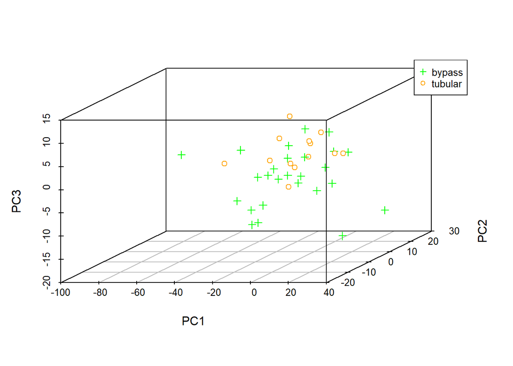

```r
gr3Ddata <- as.data.frame(PCAseMA$x)
gr3Ddata$cirugia <- cirugian
library(scatterplot3d)
# scatterplot3d(PCAseMA$x[,1], PCAseMA$x[,2], PCAseMA$x[,3],
scatterplot3d(gr3Ddata[,1], gr3Ddata[,2], gr3Ddata[,3],
              xlab="PC1", ylab="PC2", zlab="PC3",
              color = ifelse(gr3Ddata$cirugia == "1", "green", "orange"),
              pch = ifelse(gr3Ddata$cirugia == "1", 3, 21))
legend("topright",
       pch=c(3,21),
       col=c("green","orange"),
       cex=0.8,
       legend=c("bypass","tubular"))
```

## 7. Cerca de patrons

Ho farem amb un heatmap de la matriu de correlacions que permetria veure totes les relacions

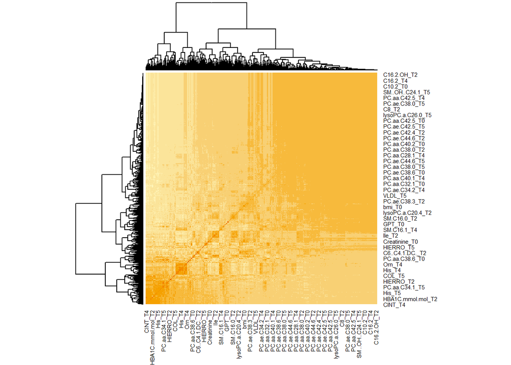

```r
cor_matrix <- cor(na.omit(assay(seMAnormalized)))
heatmap(cor_matrix)
```

Es veuen dos grups de variables més correlacionades, però en general les correlacions són debils.

Ara fem un altre heatmap que calcula distancies entre les variables i les mostres

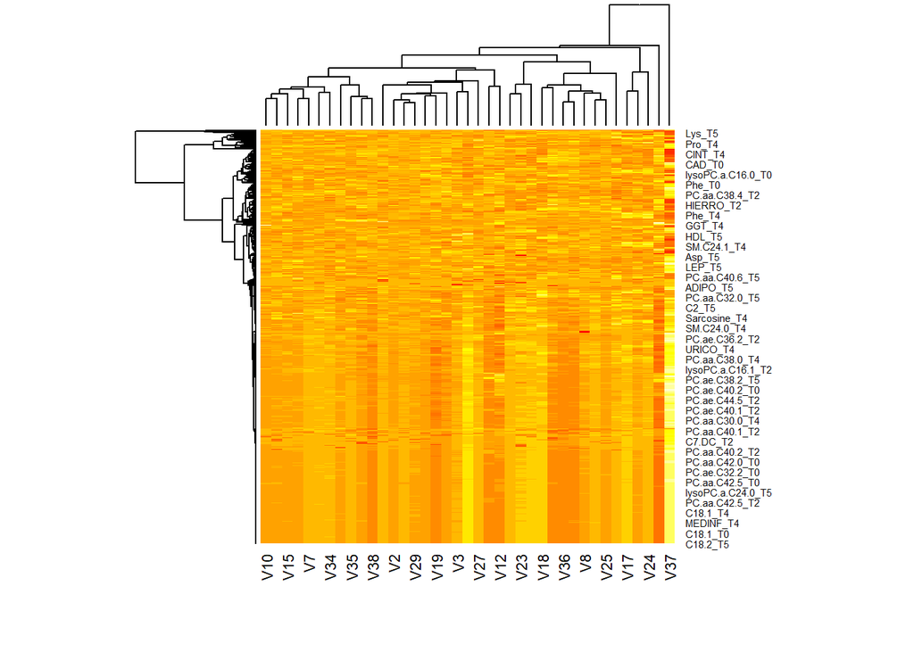

```r
dist_matrix <- t(assay(seMAnormalized))
heatmap(dist_matrix, col=heat.colors(16))
```

Hi ha tantes mostres i variables que no es poden veure be totes les relacions, però sembla que hi ha un patró clar de proximitat en les primeres variables del gràfic i algunes que estan a molta distància cap a baix.